# DS Lab 4

Mia Raghavan, Julie Jung, Dion Ho, Vincent Feng

9/13/2019

```r
train <- read.csv("train.csv")
```

# Exercise 1

*Do the values in count seem to be distributed according to a Poisson distribution?*

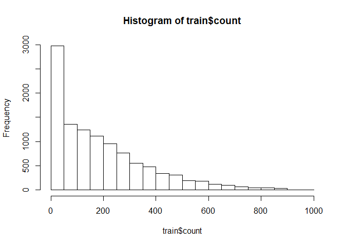

```r
hist(train$count)
```

The right-skewed histogram indicates that the values in count are distributed according to a Poisson distribution with a small $\sigma$ parameter.

# Exercise 2

*Fit a poisson regression model with count as outcome and workingday as only predictor.*

```r
train_po <- glm(count ~ workingday, family = "poisson", data = train)
summary(train_po)
```

```
##
## Call:
## glm(formula = count ~ workingday, family = "poisson", data = train)
##
## Deviance Residuals:
##     Min       1Q   Median       3Q      Max
## -19.326  -13.035   -3.537    6.179   40.011
##
## Coefficients:
##             Estimate Std. Error z value Pr(>|z|)
## (Intercept) 5.239133   0.001236 4239.73   <2e-16 ***
## workingday  0.023619   0.001492   15.83   <2e-16 ***
## ---
## Signif. codes:  0 '***' 0.001 '**' 0.01 '*' 0.05 '.' 0.1 ' ' 1
##
## (Dispersion parameter for poisson family taken to be 1)
##
##     Null deviance: 1800567  on 10885  degrees of freedom
## Residual deviance: 1800315  on 10884  degrees of freedom
## AIC: 1869966
##
## Number of Fisher Scoring iterations: 5
```

# Exercise 3

*Interpret the slope from your poisson regression fit.*

The slope is 0.023619 with regard to workingday. That means, compared to a non-working day (weekend or holiday), count for a workingday is predicted to be multipled by a factor of $e^{0.023619} \approx 1.0239$.

# Exercise 4

*Is the slope practically significant?*

```r
summary(train$workingday)
```

```
##    Min. 1st Qu.  Median    Mean 3rd Qu.    Max.
##  0.0000  0.0000  1.0000  0.6809  1.0000  1.0000
```

```r
summary(train$count)
```

```
##    Min. 1st Qu.  Median    Mean 3rd Qu.    Max.
##     1.0    42.0   145.0   191.6   284.0   977.0
```

The slope is not practically significant. As stated in Q3, compared to a non-working day (weekend or holiday), count for a workingday is larger by a factor of 1.0239. Workingday ranges from 0 to 1, and so for this range, the range of count as impacted by workingday is only 0 to 1.0239, which is almost negligible compared the full range of count from 1 to 977. For example, for the mean count of 191.5741319, an increase by a factor of 1.0239 would increase the count by 4.5786218 units, which is not a practically significant addition to 191.5741319.

# Exercise 5

*Is the slope statistically significant?*

The slope is statistically significant, as the p value is <2e-16, which is lower than the significance level 0.05, hence we reject the null hypothesis.

# Exercise 6

*Fit a negative binomial regression model with count as outcome and workingday as only predictor.*

```r
library(MASS)
train_nb <- glm.nb(count ~ workingday, data = train)
summary(train_nb)
```

```
##
## Call:
## glm.nb(formula = count ~ workingday, data = train, init.theta = 0.851005398,
##     link = log)
##
## Deviance Residuals:
##     Min       1Q   Median       3Q      Max
## -2.5873  -1.1058  -0.2455   0.3837   2.0349
##
## Coefficients:
##             Estimate Std. Error z value Pr(>|z|)
## (Intercept)  5.23913    0.01843 284.225   <2e-16 ***
## workingday   0.02362    0.02234   1.057     0.29
## ---
## Signif. codes:  0 '***' 0.001 '**' 0.01 '*' 0.05 '.' 0.1 ' ' 1
##
## (Dispersion parameter for Negative Binomial(0.851) family taken to be 1)
##
##     Null deviance: 12738  on 10885  degrees of freedom
## Residual deviance: 12737  on 10884  degrees of freedom
## AIC: 136063
##
## Number of Fisher Scoring iterations: 1
##
##
##               Theta:  0.8510
##           Std. Err.:  0.0102
##
##  2 x log-likelihood:  -136056.6550
```

# Exercise 7

*Does the interpretation of the slope change compared to the poisson regression fit?*

The slope is 0.02362, which is slightly different from the slope of 0.023619 from the poisson regression link. Nonetheless, the interpretation of the slope is the same since both the poisson and the negative binomial models are GLMs with the same link function.

# Exercise 8

*Is the slope statistically significant?*

The slope is not statistically significant. Its p-value is 0.29, which is greater than the set significance level of 0.05. We thus fail to reject the null hypothesis.

# Exercise 9

*What is a potential explanation for the difference in p-value obtained for the slope between poisson regression and negative binomial regression?*

Negative binomial regression captures the overdispersion in the data better than poisson does. It captures more accurately the full extent of the variability, which is usually larger than the variability captured in a poisson distribution, the negative binomial model will reflect greater uncertainty in the best-fit line and therefore the p-value is higher.

# Exercise 10

*Fit a negative binomial regression with count as outcome and temp, atemp, humidity, and workingday as predictors. Which variable(s) are not statistically significant? Can you provide an explanation for this based on the data context?*

```r
library(MASS)
train_nb2 <- glm.nb(count ~ workingday + temp + atemp + humidity, data = train)
summary(train_nb2)
```

```
##
## Call:
## glm.nb(formula = count ~ workingday + temp + atemp + humidity,
##     data = train, init.theta = 1.005429879, link = log)
##
## Deviance Residuals:
##     Min       1Q   Median       3Q      Max
## -2.9596  -0.9877  -0.2331   0.3357   3.4537
##
## Coefficients:
##              Estimate Std. Error z value Pr(>|z|)
## (Intercept)  4.929109   0.045233 108.971  < 2e-16 ***
## workingday   0.087602   0.020594   4.254  2.1e-05 ***
## temp         0.010486   0.007184   1.460    0.144
## atemp        0.036111   0.006597   5.474  4.4e-08 ***
## humidity    -0.014771   0.000503 -29.367  < 2e-16 ***
## ---
## Signif. codes:  0 '***' 0.001 '**' 0.01 '*' 0.05 '.' 0.1 ' ' 1
##
## (Dispersion parameter for Negative Binomial(1.0054) family taken to be 1)
##
##     Null deviance: 14995  on 10885  degrees of freedom
## Residual deviance: 12507  on 10881  degrees of freedom
## AIC: 133784
##
## Number of Fisher Scoring iterations: 1
##
##
##               Theta:  1.0054
##           Std. Err.:  0.0123
##
##  2 x log-likelihood:  -133771.6160
```

Temp, the variable representing the temperature in Celcius, is not statistically significant. This may be the case because bike riders are more sensitive to what the temperature “feels like” rather than the actual temperature. This information is captured in the variable atemp.

# Exercise 11

*Interpret the coefficient for humidity.*

The coefficient for humidity is -0.014771. It means that for every one unit increase in humidity, count is multiplied by a factor of 0.9853376 - that is, a 1.5% decrease.

# Exercise 12

*Visualize count and atemp jointly such that one can inspect these data. The goal is to creat a figure that is easy to understand. It does not have to show every single data point.*

We start with a very simple scatter plot between count and atemp.

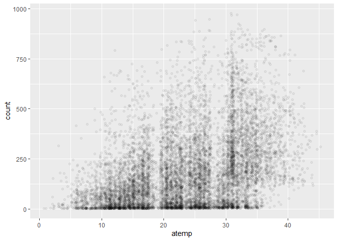

```r
library(ggplot2)
ggplot(train, aes(x = atemp, y = count)) +
    geom_jitter(alpha=1/20) +
    theme_gray()
```

Since we don’t have to see every single point, we add jitter and transparency to it so that we can better see the density and relative distribution.

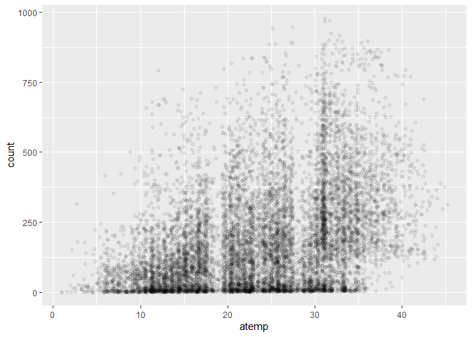

```r
ggplot(train, aes(x = atemp, y = count)) +
    geom_point(alpha=1/15,position=position_jitter(h=0)) +
    theme_gray()
```

Finally, we overlay the chart with summary lines (black line depicts the mean while blue line depicts the median), for more intuitive grasp of the key trend of count across the range of atemp.

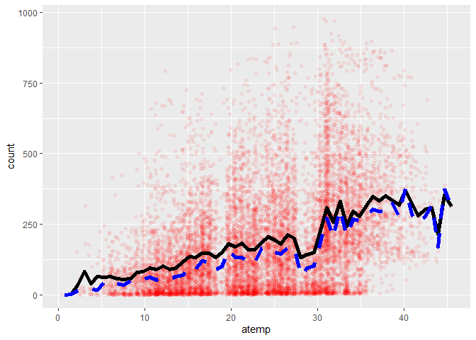

```r
ggplot(train, aes(x = atemp, y = count)) +
    geom_point(alpha=1/15,position=position_jitter(h=0), color="red") +
    geom_line(stat='summary',fun.y=mean, size = 2) +
    geom_line(stat='summary',fun.y=median,linetype=2,color='blue', size = 2)
```